# Principal Components Analysis: Granatosky et al. 2014

Kelly Ostrofsky

April 6, 2015

# Granatosky et al. 2014 - Lumbar vertebral morphology of flying, gliding, and suspensory mammals: Implications for the locomotor behavior of the subfossil lemurs *Palaeopropithecus* and *Babakotia*

## Summary:

In this paper, the authors look at lumbar vertebral morphology to reconstruct locomotor behavior, in this case with respect to subfossil lemurs, *Palaeopropithecus* and *Babakotia*. They used seven measurements of the lumbar vertebrae that were chosen based on their functional significance, mostly with respect to their contribution to axial rigidity or mobility.

They describe locomotion such as inverted quadrupedalism, gliding, and flying as potentially requiring a more rigid spine. Previous studies found it difficult to distinguish these behaviors based on morphology, so this study used the lumbar vertebrae to try and make more fine-grained distinctions among different mammalian species, to better describe how the axial skeleton affects locomotor behavior in these extant mammals. This was then applied to two extinct species of sloth lemurs (*Palaeopropithecus* and *Babakotia*).

The previous reconstructions of *Palaeopropithecus* suggest it to be a more specialized inverted quadruped, like extant sloths. *Babakotia* is considered antipronograde, similar to living lorisids. Their hypotheses:

1. There is a relationship between locomotor behavior and vertebral morphology
   - antipronograde, mitten-gliding, inverted quadrupeds, gliding, flying → more axial RIGIDITY
   - pronograde, vertical clinging and leaping → more axial MOBILITY
2. Distinctions related to locomotor behavior can aid in the reconstruction of locomotor behavior of fossil species
   - sloth lemurs will occupy a similar morphospace to living inverted quadrupeds and/or antipronograde mammals

The linear measurements were divided by the geometric mean to account for effects of body size variation. They used PCA to explore variation in the metric data and examine the distribution of sample taxa in multidimensional morphospace. Linear variables were also log-transformed to normalize the distribution data for each species sample. The PCA was conducted using the correlation matrix in JMP. Now we will do it in R…

## Read in the data

```r
library(dplyr)
```

```r
library(ggplot2)

data<- read.table("http://hompal-stats.wabarr.com/datasets/granatoskydata.csv", sep=",", na.strings="", header=T)

#log-transform the linear variables, and then select the variables of interest
data_log<- mutate(data,
                  lnDVHSP=log(DVHSP),
                  lnCCLSP=log(CCLSP),
                  lnMLLTP=log(MLLTP),
                  lnDVHVB=log(DVHVB),
                  lnMLWVB=log(MLWVB),
                  lnCCLVB=log(CCLVB)) %>%
  select(Sp., SPECIES, Locomotor_category, Family,
         lnDVHSP, lnCCLSP, lnMLLTP, DVOTP, lnDVHVB, lnMLWVB, lnCCLVB)

head(data_log)
```

```
##   Sp.                 SPECIES Locomotor_category       Family    lnDVHSP
## 1  AC Arctocebus calabarensis     Antipronograde    Lorisidae -0.3856625
## 2  LT       Loris tardigradus     Antipronograde    Lorisidae -0.8675006
## 3  NC      Nycticebus coucang     Antipronograde    Lorisidae -0.3856625
## 4  PP      Perodicticus potto     Antipronograde    Lorisidae -0.5447272
## 5  CD     Caluromys derbianus     Antipronograde Caluromyidae  0.1397619
## 6  CL       Caluromys lanatus     Antipronograde Caluromyidae  0.2700271
##     lnCCLSP    lnMLLTP  DVOTP     lnDVHVB   lnMLWVB   lnCCLVB
## 1 0.3715636 -0.4462871 106.90 -0.23572233 0.3293037 0.3784364
## 2 0.5877867 -0.5621189 112.44 -0.01005034 0.3364722 0.5247285
## 3 0.1043600 -0.4462871  95.43  0.04879016 0.3148107 0.4382549
## 4 0.3852624 -0.3710637 101.85 -0.07257069 0.2390169 0.4187103
## 5 0.9932518  0.2851789 108.10  0.17395331 0.5822156 1.1378330
## 6 1.1878434  0.1988509 104.00  0.29266961 0.7080358 1.3480731
```

```r
#now have log-transformed linear data (DVOTP is an angle, not log-transformed) of the species geomean-adjusted means, including the extant and subfossil taxa
```

## PCA in R

There are several functions you can use to do PCA in R. I’m going to go through one of them in detail, and then give examples of how to use the others (if you ever want to do a PCA, you’ll have plenty of code to look at).

### PCA using prcomp() function in basic stats package

Help page for prcomp(): The calculation is done by a singular value decomposition of the (centered and possibly scaled) data matrix, not by using eigen on the covariance matrix. *This is generally the preferred method for numerical accuracy.*

```r
vertpca1<- prcomp(data_log[,5:11], scale.=TRUE)
#scale.= is whether or not the variables should be scaled to have unit variance before the analysis; default is scale.=F, but usually you would use T

vertpca1
```

```
## Standard deviations:
## [1] 1.9222884 1.3385384 0.7894574 0.5732121 0.4879514 0.4747846 0.3127140
##
## Rotation:
##                PC1         PC2         PC3          PC4        PC5
## lnDVHSP  0.3294381 -0.40462832 -0.59205404  0.085462011  0.5421158
## lnCCLSP -0.4737683 -0.16250223 -0.13910732  0.207976158 -0.3356351
## lnMLLTP  0.2398731 -0.46903500  0.76585985 -0.002439403  0.1762592
## DVOTP    0.4459607 -0.24572496 -0.04175674  0.203311032 -0.3187549
## lnDVHVB -0.4552946 -0.04724347  0.15187543  0.624444931  0.4882457
## lnMLWVB -0.4052694 -0.31479335 -0.01554517 -0.710189078  0.2369377
## lnCCLVB -0.1976302 -0.65434514 -0.13611919  0.117476967 -0.4077550
##                 PC6         PC7
## lnDVHSP -0.23994751  0.13583212
## lnCCLSP -0.33194517  0.68095017
## lnMLLTP -0.28008091  0.16250288
## DVOTP    0.68429938  0.35747580
## lnDVHVB  0.36663391 -0.06835919
## lnMLWVB  0.38686376  0.16201440
## lnCCLVB -0.03798224 -0.57683509
```

```r
#FACTOR LOADINGS - these tell you what is driving the shape variation on each of the components
vertpca1$rotation
```

```
##                PC1         PC2         PC3          PC4        PC5
## lnDVHSP  0.3294381 -0.40462832 -0.59205404  0.085462011  0.5421158
## lnCCLSP -0.4737683 -0.16250223 -0.13910732  0.207976158 -0.3356351
## lnMLLTP  0.2398731 -0.46903500  0.76585985 -0.002439403  0.1762592
## DVOTP    0.4459607 -0.24572496 -0.04175674  0.203311032 -0.3187549
## lnDVHVB -0.4552946 -0.04724347  0.15187543  0.624444931  0.4882457
## lnMLWVB -0.4052694 -0.31479335 -0.01554517 -0.710189078  0.2369377
## lnCCLVB -0.1976302 -0.65434514 -0.13611919  0.117476967 -0.4077550
##                 PC6         PC7
## lnDVHSP -0.23994751  0.13583212
## lnCCLSP -0.33194517  0.68095017
## lnMLLTP -0.28008091  0.16250288
## DVOTP    0.68429938  0.35747580
## lnDVHVB  0.36663391 -0.06835919
## lnMLWVB  0.38686376  0.16201440
## lnCCLVB -0.03798224 -0.57683509
```

```r
loadings<- vertpca1$rotation[,c("PC1", "PC2", "PC3")] #save these for reference later

#PC SCORES - these are the scores for each datapoint on each principal component
PCscores1<- vertpca1$x %>% as.data.frame()
head(PCscores1)
```

```
##          PC1        PC2         PC3         PC4         PC5        PC6
## 1 -0.4929661  1.0823953 -1.00223766 -0.49517675 -0.37564066  0.1018735
## 2 -1.3579665  0.9934919 -0.79388914  0.20753718 -1.04076032  0.9579051
## 3 -1.2595607  1.2486458 -0.75166422 -0.06793455  0.56418130 -0.1174251
## 4 -0.9064650  1.1965366 -0.54173777  0.09048467 -0.20468576 -0.1744351
## 5 -1.8846529 -3.0791099 -0.09144264  0.35848726 -0.04457970 -0.2080122
## 6 -2.8305833 -3.7576919 -0.54084597  0.34742489  0.05590631 -0.2183795
##           PC7
## 1  0.57481500
## 2  0.47104884
## 3 -0.38561575
## 4  0.21726421
## 5  0.28141112
## 6 -0.04094716
```

```r
#PROPORTION OF VARIANCE EXPLAINED
vertpca1.results <- summary(vertpca1)
vertpca1.results
```

```
## Importance of components:
##                           PC1    PC2     PC3     PC4     PC5    PC6
## Standard deviation     1.9223 1.3385 0.78946 0.57321 0.48795 0.4748
## Proportion of Variance 0.5279 0.2560 0.08903 0.04694 0.03401 0.0322
## Cumulative Proportion  0.5279 0.7838 0.87287 0.91981 0.95383 0.9860
##                            PC7
## Standard deviation     0.31271
## Proportion of Variance 0.01397
## Cumulative Proportion  1.00000
```

```r
#save PVEs for later
PC1.pve<- vertpca1.results$importance[2]
PC2.pve<- vertpca1.results$importance[5]
PC3.pve<- vertpca1.results$importance[8]
```

#### Making the PCA plot

```r
#The plot is grouped by locomotor category for the extant taxa, with the fossils as separate groups. So you need to put the fossil genus as locomotor category so it will be plotted correctly (when mapping shape or color to 'locomotor category' variable)
legendlabels<- factor(c("Babakotia", "Palaeopropithecus", "Antipronograde", "Flight", "Gliding", "Inverted quadrupedalism", "Mitten-gliding", "Pronograde", "Vertical clinging"))
legendlabels<- ordered(legendlabels, levels=legendlabels)

#The locomotor category variable is currently a factor, so I need to change it to the ordered factor I just made, so it will let me add in the fossil names
data_log$Locomotor_category <- ordered(data_log$Locomotor_category, levels=legendlabels)
data_log[38,3] <- "Palaeopropithecus"
data_log[39,3] <- "Babakotia"
```

##### PLOT PC1 vs. PC2

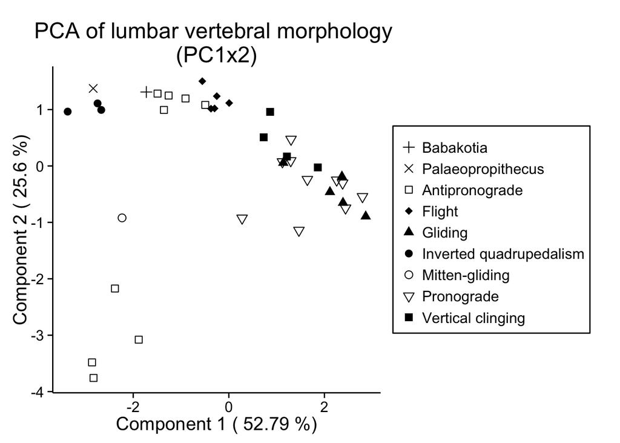

```r
PLOTA_1x2 <- ggplot(data=PCscores1,
       aes(x=PC1, y=PC2, shape=data_log$Locomotor_category)) +
  geom_point(size=3) + theme_classic(15) +
  labs(title="PCA of lumbar vertebral morphology \n(PC1x2)",
       x=paste("Component 1 (",round(100*PC1.pve,2),"%)"),
       y=paste("Component 2 (",round(100*PC2.pve,2),"%)")) +
  theme(legend.title=element_blank(), legend.background=element_rect(color="black")) +
scale_shape_manual(labels=legendlabels,
                     values=c(3, 4, 22, 18, 17, 16, 1, 6, 15))
PLOTA_1x2
```

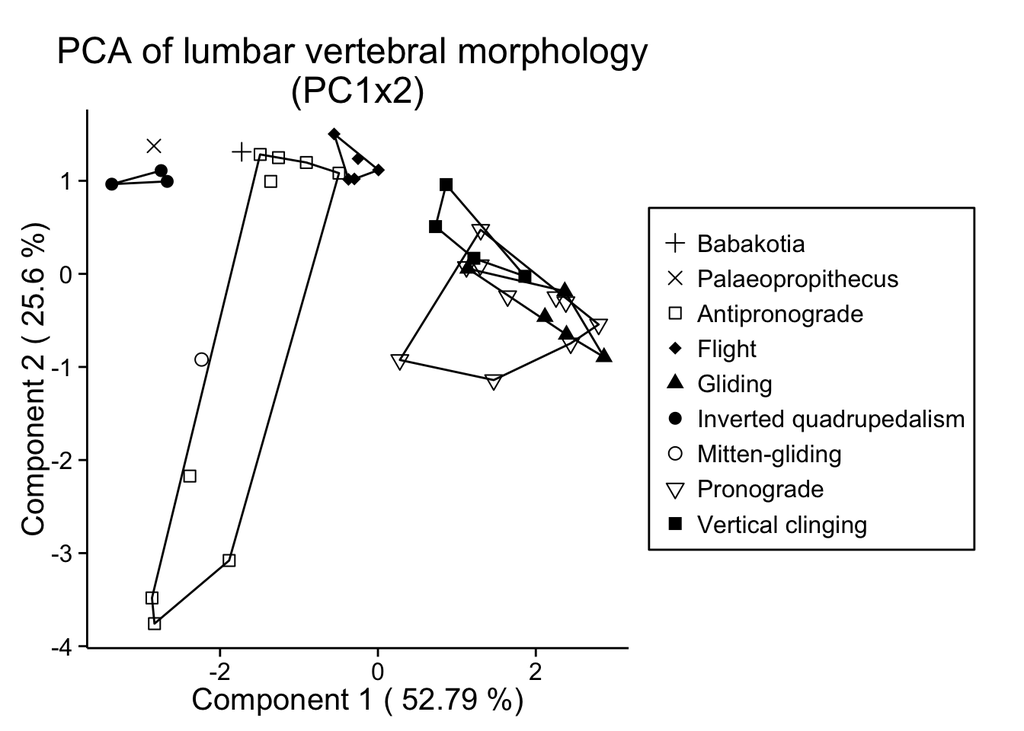

```r
#ADD CONVEX HULLS
#right now, the PC scores are in a dataframe by themselves, so I'm just adding the locomotor category columns to that dataframe (also species in case I want to go back and look at a specific datapoint)
PCscores1$Locomotor_category<- data_log$Locomotor_category
PCscores1$SPECIES<- data_log$SPECIES
library(grDevices)

#creating dataframe with the relevant PC scores and Locomotor category; will have to subset the data by locomotor category to make the convex hulls
scoresvert1<- select(PCscores1, Locomotor_category, SPECIES, PC1, PC2, PC3)

antipro <- scoresvert1[scoresvert1$Locomotor_category=="Antipronograde",] %>%
  select(PC1, PC2)
flight <- scoresvert1[scoresvert1$Locomotor_category=="Flight",] %>%
  select(PC1, PC2)
gliding <- scoresvert1[scoresvert1$Locomotor_category=="Gliding",] %>%
  select(PC1, PC2)
invertquad <- scoresvert1[scoresvert1$Locomotor_category=="Inverted quadrupedalism",] %>%
  select(PC1, PC2)
mittenglid<- scoresvert1[scoresvert1$Locomotor_category=="Mitten-gliding",] %>%
  select(PC1, PC2)
pronograde<- scoresvert1[scoresvert1$Locomotor_category=="Pronograde",] %>%
  select(PC1, PC2)
vertcling<- scoresvert1[scoresvert1$Locomotor_category=="Vertical clinging",] %>%
  select(PC1, PC2)


polygon_PLOTA_1x2 <- PLOTA_1x2 +
  geom_polygon(inherit.aes=F, data=antipro[chull(antipro),],
               aes(x=PC1, y=PC2), alpha=0, linetype=1, color="black") +
  geom_polygon(inherit.aes=F, data=flight[chull(flight),],
               aes(x=PC1, y=PC2), alpha=0, linetype=1, color="black") +
  geom_polygon(inherit.aes=F, data=gliding[chull(gliding),],
               aes(x=PC1, y=PC2), alpha=0, linetype=1, color="black") +
  geom_polygon(inherit.aes=F, data=invertquad[chull(invertquad),],
               aes(x=PC1, y=PC2), alpha=0, linetype=1, color="black") +
  geom_polygon(inherit.aes=F, data=mittenglid[chull(mittenglid),],
               aes(x=PC1, y=PC2), alpha=0, linetype=1, color="black") +
  geom_polygon(inherit.aes=F, data=pronograde[chull(pronograde),],
               aes(x=PC1, y=PC2), alpha=0, linetype=1, color="black") +
  geom_polygon(inherit.aes=F, data=vertcling[chull(vertcling),],
               aes(x=PC1, y=PC2), alpha=0, linetype=1, color="black")

polygon_PLOTA_1x2
```

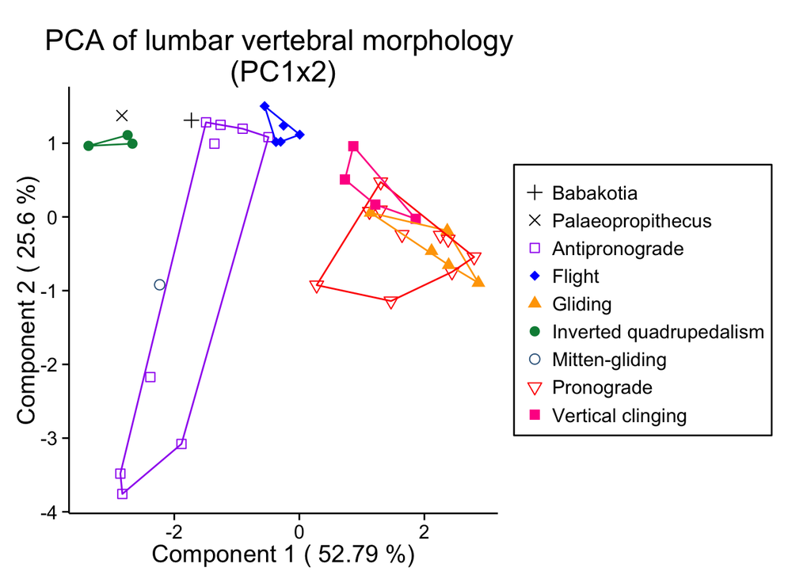

```r
#actually a lot easier to read when color-coded instead of black and white
PLOTA_color_1x2<- ggplot(data=PCscores1, aes(x=PC1, y=PC2, shape=data_log$Locomotor_category, color=data_log$Locomotor_category)) +
  geom_point(size=3) + theme_classic(15) +
  labs(title="PCA of lumbar vertebral morphology \n(PC1x2)",
       x=paste("Component 1 (",round(100*PC1.pve,2),"%)"),
       y=paste("Component 2 (",round(100*PC2.pve,2),"%)")) +
  theme(legend.title=element_blank(),
        legend.background=element_rect(color="black")) +
  scale_shape_manual(labels=legendlabels,
                     values=c(3, 4, 22, 18, 17, 16, 1, 6, 15)) +
  scale_color_manual(labels=legendlabels,
                     values=c("black", "black", "purple", "blue", "orange",
                              "springgreen4", "steelblue4", "red", "deeppink")) +
  geom_polygon(inherit.aes=F, data=antipro[chull(antipro),],
               aes(x=PC1, y=PC2), alpha=0, linetype=1, color="purple") +
  geom_polygon(inherit.aes=F, data=flight[chull(flight),],
               aes(x=PC1, y=PC2), alpha=0, linetype=1, color="blue") +
  geom_polygon(inherit.aes=F, data=gliding[chull(gliding),],
               aes(x=PC1, y=PC2), alpha=0, linetype=1, color="orange") +
  geom_polygon(inherit.aes=F, data=invertquad[chull(invertquad),],
               aes(x=PC1, y=PC2), alpha=0, linetype=1, color="springgreen4") +
  geom_polygon(inherit.aes=F, data=mittenglid[chull(mittenglid),],
               aes(x=PC1, y=PC2), alpha=0, linetype=1, color="steelblue4") +
  geom_polygon(inherit.aes=F, data=pronograde[chull(pronograde),],
               aes(x=PC1, y=PC2), alpha=0, linetype=1, color="red") +
  geom_polygon(inherit.aes=F, data=vertcling[chull(vertcling),],
               aes(x=PC1, y=PC2), alpha=0, linetype=1, color="deeppink")

PLOTA_color_1x2
```

```r
loadings #just look at this again to interpret the plot
```

```
##                PC1         PC2         PC3
## lnDVHSP  0.3294381 -0.40462832 -0.59205404
## lnCCLSP -0.4737683 -0.16250223 -0.13910732
## lnMLLTP  0.2398731 -0.46903500  0.76585985
## DVOTP    0.4459607 -0.24572496 -0.04175674
## lnDVHVB -0.4552946 -0.04724347  0.15187543
## lnMLWVB -0.4052694 -0.31479335 -0.01554517
## lnCCLVB -0.1976302 -0.65434514 -0.13611919
```

- Looking at PC1, this separates:
  - Inverted quadrupeds (green), mitten-gliders (blue circle), flying chiropterans (blue), and antipronograde mammals (purple) on the LEFT [rigidity] from the other locomotor groups on the RIGHT [mobility] (gliding, vertical clinging, pronograde)
  - Referring to the factor loadings, this means that the groups on the LEFT have: relatively cranio-caudally long and dorsoventrally short spinous processes, dorsally oriented transverse processes, and dorsoventrally and mediolaterally elongated width of the vertebral bodies (tall and wide)
  - Also note that both of the subfossil lemurs have low scores on PC1
- On PC2 (note mine is kind of different..), the separation they describe is mostly of the gliding/flying mammals (orange, blue) from inverted quadrupeds (green). In their graph, the subfossil lemurs are intermediate, close to the antipronograde mammals, but in mine… the antipronograde kind of extends all the way along PC2. Oh well.

We can make the PC1 vs. PC3 graph now:

##### PLOT PC1 x PC3

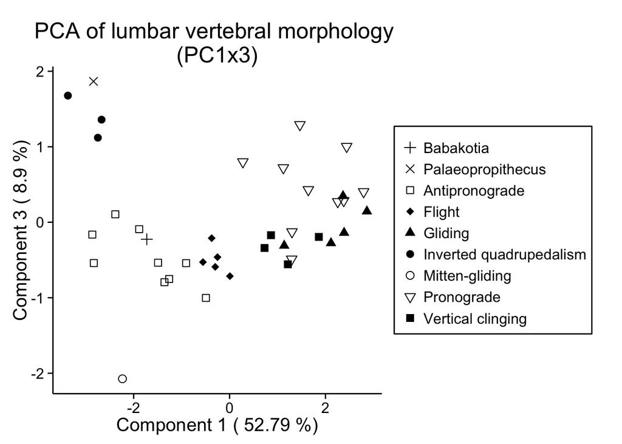

```r
PLOTA_1x3 <- ggplot(data=PCscores1,
       aes(x=PC1, y=PC3, shape=data_log$Locomotor_category)) +
  geom_point(size=3) + theme_classic(15) +
  labs(title="PCA of lumbar vertebral morphology \n(PC1x3)",
       x=paste("Component 1 (",round(100*PC1.pve,2),"%)"),
       y=paste("Component 3 (",round(100*PC3.pve,2),"%)")) +
  theme(legend.title=element_blank(), legend.background=element_rect(color="black")) +
scale_shape_manual(name="Locomotor category",
                     labels=legendlabels,
                     values=c(3, 4, 22, 18, 17, 16, 1, 6, 15))
PLOTA_1x3
```

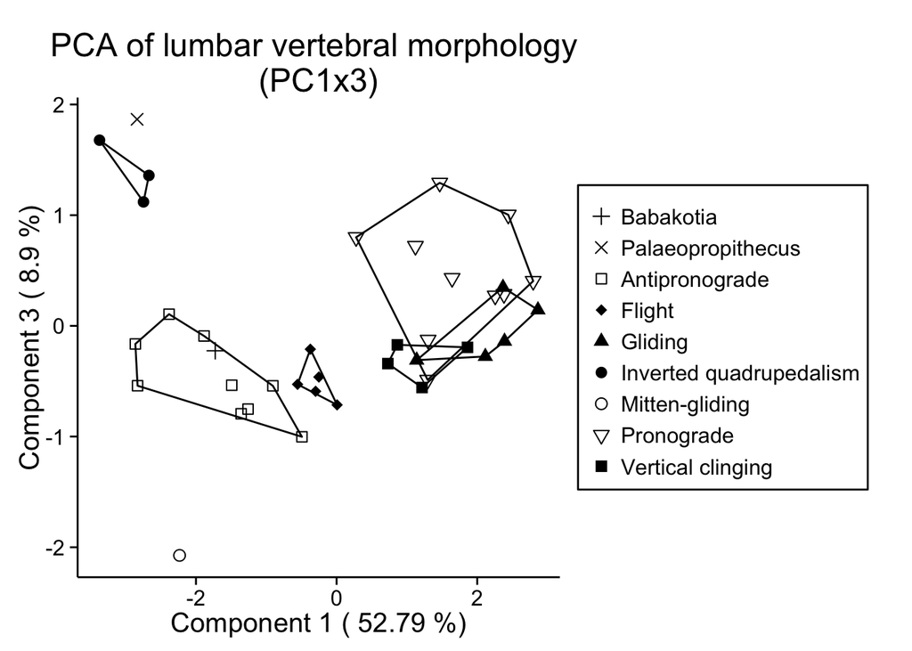

```r
#ADD CONVEX HULLS
#need to just have PC1 and PC3 scores for each locomotor group, so subset the data again:
antipro3 <- scoresvert1[scoresvert1$Locomotor_category=="Antipronograde",] %>%
  select(PC1, PC3)
flight3 <- scoresvert1[scoresvert1$Locomotor_category=="Flight",] %>%
  select(PC1, PC3)
gliding3 <- scoresvert1[scoresvert1$Locomotor_category=="Gliding",] %>%
  select(PC1, PC3)
invertquad3 <- scoresvert1[scoresvert1$Locomotor_category=="Inverted quadrupedalism",] %>%
  select(PC1, PC3)
mittenglid3<- scoresvert1[scoresvert1$Locomotor_category=="Mitten-gliding",] %>%
  select(PC1, PC3)
pronograde3<- scoresvert1[scoresvert1$Locomotor_category=="Pronograde",] %>%
  select(PC1, PC3)
vertcling3<- scoresvert1[scoresvert1$Locomotor_category=="Vertical clinging",] %>%
  select(PC1, PC3)

polygon_PLOTA_1x3 <- PLOTA_1x3 +
  geom_polygon(inherit.aes=F, data=antipro3[chull(antipro3),],
               aes(x=PC1, y=PC3), alpha=0, linetype=1, color="black") +
  geom_polygon(inherit.aes=F, data=flight3[chull(flight3),],
               aes(x=PC1, y=PC3), alpha=0, linetype=1, color="black") +
  geom_polygon(inherit.aes=F, data=gliding3[chull(gliding3),],
               aes(x=PC1, y=PC3), alpha=0, linetype=1, color="black") +
  geom_polygon(inherit.aes=F, data=invertquad3[chull(invertquad3),],
               aes(x=PC1, y=PC3), alpha=0, linetype=1, color="black") +
  geom_polygon(inherit.aes=F, data=mittenglid3[chull(mittenglid3),],
               aes(x=PC1, y=PC3), alpha=0, linetype=1, color="black") +
  geom_polygon(inherit.aes=F, data=pronograde3[chull(pronograde3),],
               aes(x=PC1, y=PC3), alpha=0, linetype=1, color="black") +
  geom_polygon(inherit.aes=F, data=vertcling3[chull(vertcling3),],
               aes(x=PC1, y=PC3), alpha=0, linetype=1, color="black")

polygon_PLOTA_1x3
```

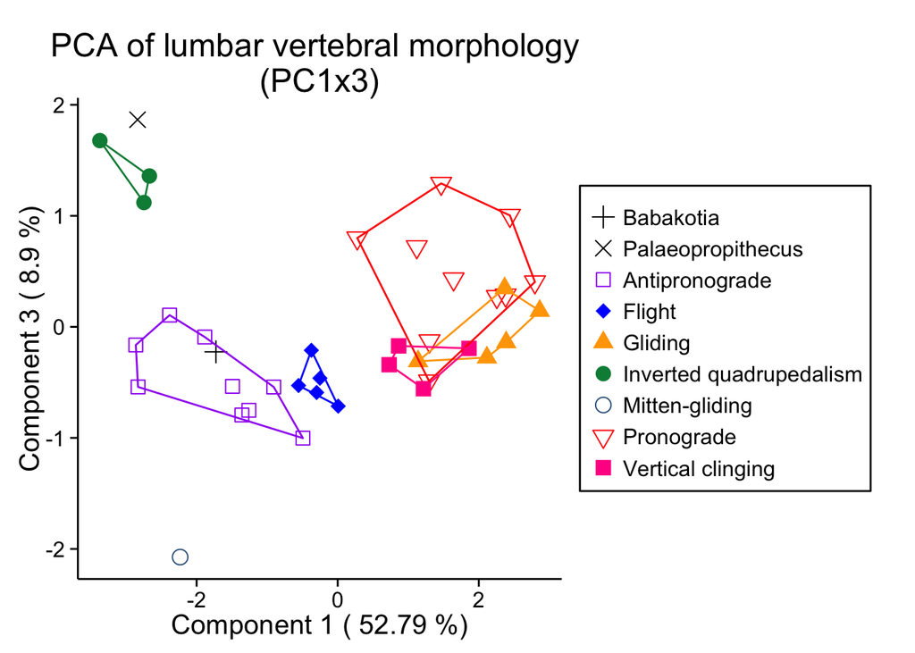

```r
#same thing again but color-coded
PLOTA_color_1x3 <- ggplot(data=PCscores1, aes(x=PC1, y=PC3, shape=data_log$Locomotor_category, color=data_log$Locomotor_category)) +
  geom_point(size=4) + theme_classic(15) +
  labs(title="PCA of lumbar vertebral morphology \n(PC1x3)",
       x=paste("Component 1 (",round(100*PC1.pve,2),"%)"),
       y=paste("Component 3 (",round(100*PC3.pve,2),"%)")) +
  theme(legend.title=element_blank(),
        legend.background=element_rect(color="black")) +
  scale_shape_manual(labels=legendlabels,
                     values=c(3, 4, 22, 18, 17, 16, 1, 6, 15)) +
  scale_color_manual(labels=legendlabels,
                     values=c("black", "black", "purple", "blue", "orange",
                              "springgreen4", "steelblue4", "red", "deeppink")) +
  geom_polygon(inherit.aes=F, data=antipro3[chull(antipro3),],
               aes(x=PC1, y=PC3), alpha=0, linetype=1, color="purple") +
  geom_polygon(inherit.aes=F, data=flight3[chull(flight3),],
               aes(x=PC1, y=PC3), alpha=0, linetype=1, color="blue") +
  geom_polygon(inherit.aes=F, data=gliding3[chull(gliding3),],
               aes(x=PC1, y=PC3), alpha=0, linetype=1, color="orange") +
  geom_polygon(inherit.aes=F, data=invertquad3[chull(invertquad3),],
               aes(x=PC1, y=PC3), alpha=0, linetype=1, color="springgreen4") +
  geom_polygon(inherit.aes=F, data=mittenglid3[chull(mittenglid3),],
               aes(x=PC1, y=PC3), alpha=0, linetype=1, color="steelblue4") +
  geom_polygon(inherit.aes=F, data=pronograde3[chull(pronograde3),],
               aes(x=PC1, y=PC3), alpha=0, linetype=1, color="red") +
  geom_polygon(inherit.aes=F, data=vertcling3[chull(vertcling3),],
               aes(x=PC1, y=PC3), alpha=0, linetype=1, color="deeppink")

PLOTA_color_1x3
```

```r
#FYI If you want 95% confidence ellipses instead of convex hulls using regular ggplot, you can use stat_ellipse(), which is p=0.95 default. It automatically creates ellipses by whatever you've grouped it by, or you can subset the dataframe like I've done for the convex hulls.
```

- PC3 in their analysis explains 12.4% of the variation…
  - PC3 separates mitten-gliders (blue circle), flying mammals (blue), and antipronograde mammals (purple) from the other taxa
  - Highest factor loading is the ML length of transverse processes
  - *Babakotia* has relatively short transverse processes, fits near antipronograde mammals; *Palaeopropithecus* has relatively ML elongated transverse processes

**SUMMARY OF PAPER CONCLUSIONS, in case you’re interested**

- Antipronograde, inverted quadrupeds, mitten-gliders, and flying mammals all have lumbar features associated with AXIAL RIGIDITY
- Pronograde, vertical clinging species have features associated with more AXIAL MOBILITY
- Contrary to predictions (but consistent with qualitative assessment of Boyer & Bloch 2008), **gliding** rodents and marsupials did not show features associated with stability, but rather MOBILITY

Other main results, re: subfossil lemurs, are largely consistent with previous studies:

- living sloths are the closest analog for *Palaeopropithecus* (obligate inverted quadrupeds)
- while highly suspensory, *Babakotia* may have been capable of a more generalized locomotor repertoire similar to living lorisids, or (as proposed by others) *Pongo*

Now we can just go through the other examples of how to run a PCA and different ways to plot results.

##### Plotting with ggbiplot()

This is another way to make a biplot for principal components using ggplot2.

```r
library(devtools)
install_github("ggbiplot", "vqv")
```

```
## Installing ggbiplot
## '/Library/Frameworks/R.framework/Resources/bin/R' --vanilla CMD INSTALL  \
##   '/private/var/folders/f0/8szm6pr11_l08x06hmmck7qh0000gn/T/RtmphSEgN6/devtools10611c47adda/vqv-ggbiplot-eabfc19'  \
##   --library='/Library/Frameworks/R.framework/Versions/3.1/Resources/library'  \
##   --install-tests
```

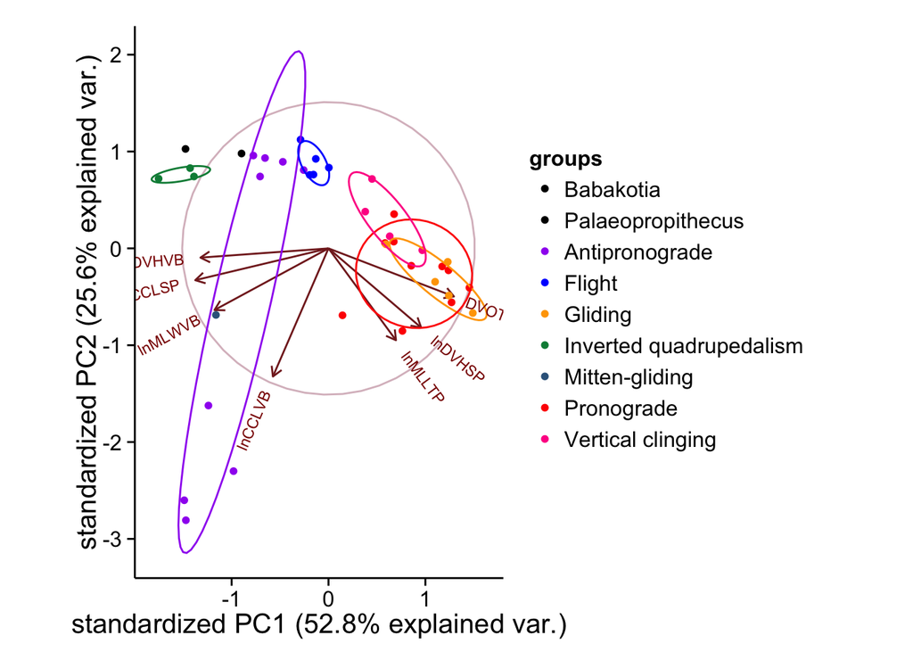

```r
library(ggbiplot)
#Plot the pca object - you can do this from prcomp() or princomp()

#Examples of some of the arguments:
###groups= is to tell it what the grouping variable is
###ellipse=T puts by default p=0.69 ellipses, but you can specify the %
###circle=T adds a correlation circle on top, shows you the projection of the variables (still will have projection of the variables if FALSE, just without the circle...)

#Example:
ggbiplot_PLOTA <- ggbiplot(vertpca1,
                           groups=data_log$Locomotor_category,
                           ellipse=TRUE, circle=TRUE) +
  theme_classic(15) +
  scale_color_manual(labels=legendlabels,
                     values=c("black", "black", "purple", "blue", "orange",
                              "springgreen4", "steelblue4", "red", "deeppink")) +
  guides(colour = guide_legend(override.aes = list(linetype=0)))

ggbiplot_PLOTA
```

### PCA using princomp() function; you can set it to cor=FALSE to use the covariance matrix.

Help page for princomp(): The calculation is done using eigen on the correlation or covariance matrix, as determined by cor. This is done for compatibility with the S-PLUS result. A preferred method of calculation is to use svd on x, as is done in prcomp.

```r
vertpca2 <- princomp(data_log[,5:11], cor=T)
vertpca2
```

```
## Call:
## princomp(x = data_log[, 5:11], cor = T)
##
## Standard deviations:
##    Comp.1    Comp.2    Comp.3    Comp.4    Comp.5    Comp.6    Comp.7
## 1.9222884 1.3385384 0.7894574 0.5732121 0.4879514 0.4747846 0.3127140
##
##  7  variables and  39 observations.
```

```r
vertpca2.results<- summary(vertpca2)
vertpca2.results #get almost exactly the same results as using prcomp()
```

```
## Importance of components:
##                           Comp.1    Comp.2     Comp.3     Comp.4    Comp.5
## Standard deviation     1.9222884 1.3385384 0.78945738 0.57321215 0.4879514
## Proportion of Variance 0.5278847 0.2559550 0.08903471 0.04693888 0.0340138
## Cumulative Proportion  0.5278847 0.7838397 0.87287439 0.91981327 0.9538271
##                            Comp.6     Comp.7
## Standard deviation     0.47478464 0.31271401
## Proportion of Variance 0.03220292 0.01397001
## Cumulative Proportion  0.98602999 1.00000000
```

```r
unclass(vertpca2$loadings) #factor loadings
```

```
##             Comp.1      Comp.2      Comp.3       Comp.4     Comp.5
## lnDVHSP  0.3294381 -0.40462832 -0.59205404  0.085462011 -0.5421158
## lnCCLSP -0.4737683 -0.16250223 -0.13910732  0.207976158  0.3356351
## lnMLLTP  0.2398731 -0.46903500  0.76585985 -0.002439403 -0.1762592
## DVOTP    0.4459607 -0.24572496 -0.04175674  0.203311032  0.3187549
## lnDVHVB -0.4552946 -0.04724347  0.15187543  0.624444931 -0.4882457
## lnMLWVB -0.4052694 -0.31479335 -0.01554517 -0.710189078 -0.2369377
## lnCCLVB -0.1976302 -0.65434514 -0.13611919  0.117476967  0.4077550
##              Comp.6      Comp.7
## lnDVHSP -0.23994751  0.13583212
## lnCCLSP -0.33194517  0.68095017
## lnMLLTP -0.28008091  0.16250288
## DVOTP    0.68429938  0.35747580
## lnDVHVB  0.36663391 -0.06835919
## lnMLWVB  0.38686376  0.16201440
## lnCCLVB -0.03798224 -0.57683509
```

```r
PCscores2 <- as.data.frame(vertpca2$scores)#save PC scores
PC1_2<- PCscores2[,1]
PC2_2 <- PCscores2[,2]
PC3_2<- PCscores2[,3]

#For this one you can't directly access the PVE, but you can calculate it (you can check it is the same by going back to the summary above)
vertpca2.propvar<- vertpca2.results$sdev^2/sum(vertpca2.results$sdev^2)
PC1_2.pve <- vertpca2.propvar[[1]]
PC2_2.pve <- vertpca2.propvar[[2]]
PC3_3.pve <- vertpca2.propvar[[3]]
```

#### Making the PCA plot

This is the same as before - you just saved the PC scores, etc. differently. Note that the results are almost the exact same as using prcomp() above.

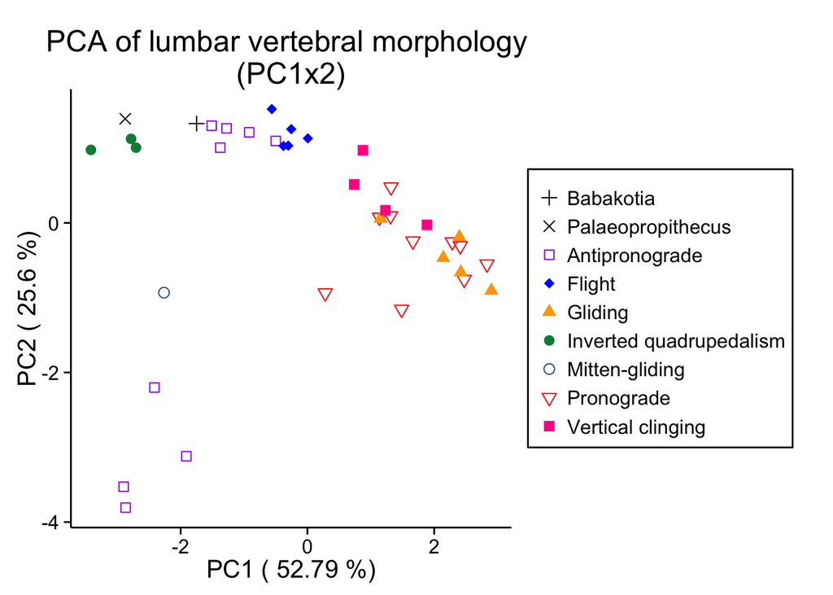

```r
#Same thing as before, plotting using ggplot: PC1xPC2
PLOTB_1x2<- ggplot(data=PCscores2, aes(x=PC1_2, y=PC2_2, color=data_log$Locomotor_category, shape=data_log$Locomotor_category)) +
  geom_point(size=3) + theme_classic(15) +
  labs(title="PCA of lumbar vertebral morphology \n(PC1x2)",
       x=paste("PC1 (",round(100*PC1_2.pve,2),"%)"),
       y=paste("PC2 (",round(100*PC2_2.pve,2),"%)")) +
  theme(legend.title=element_blank(), legend.background=element_rect(color="black")) +
  scale_shape_manual(labels=legendlabels,
                     values=c(3, 4, 22, 18, 17, 16, 1, 6, 15)) +
    scale_color_manual(labels=legendlabels,
                     values=c("black", "black", "purple", "blue", "orange",
                              "springgreen4", "steelblue4", "red", "deeppink"))

PLOTB_1x2
```

```r
#Not going to add the convex hulls... categories are color-coded, you get the idea
```

### PCA using PCA() function from FactoMineR package

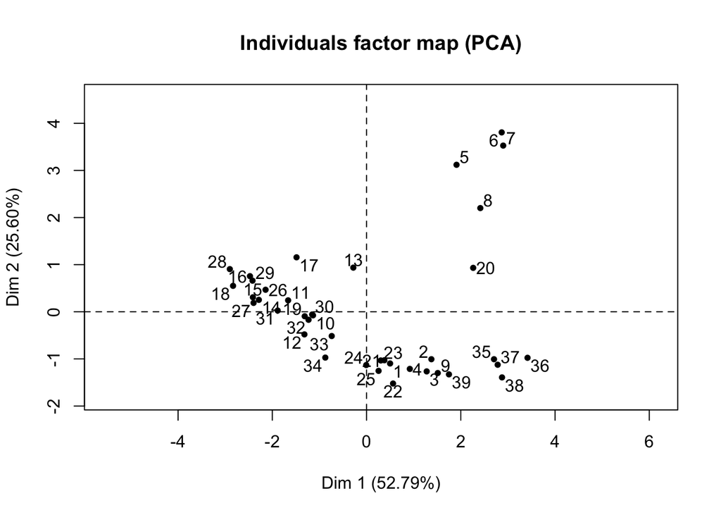

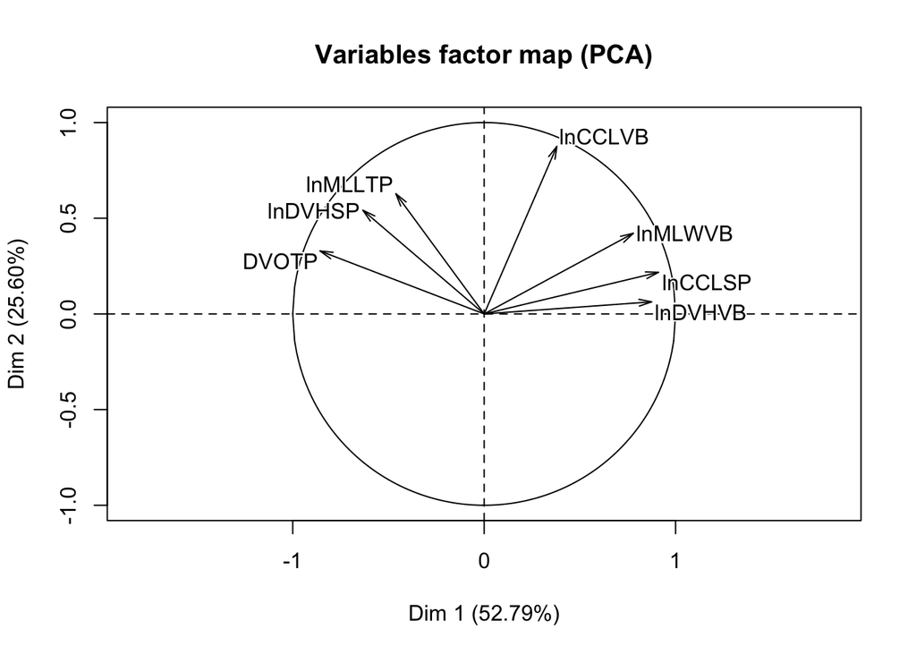

```r
library(FactoMineR)
#includes plot.PCA() function, but it just plots the individuals factor map

vertpca3 <- PCA(data_log[,5:11])
```

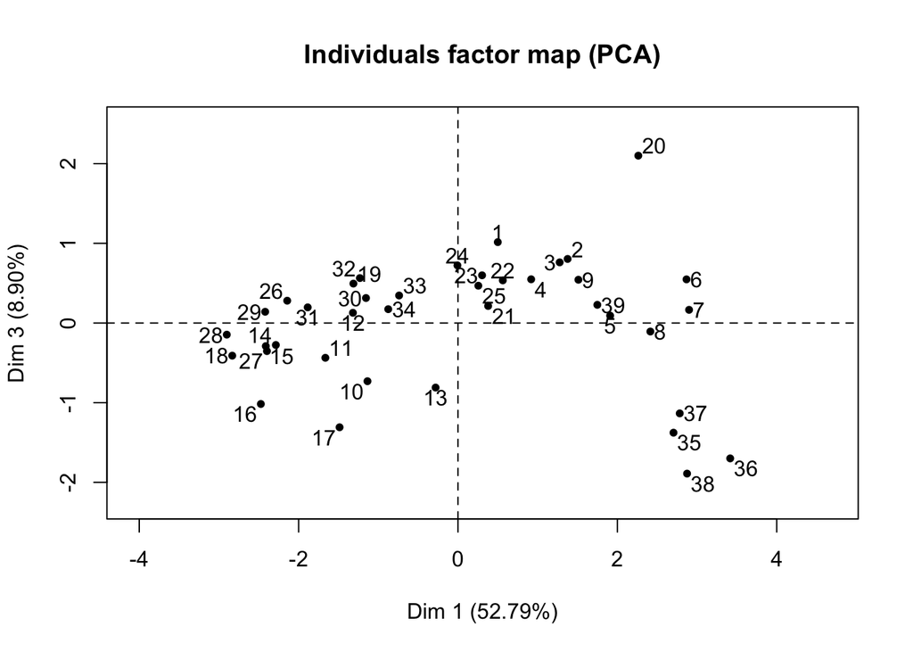

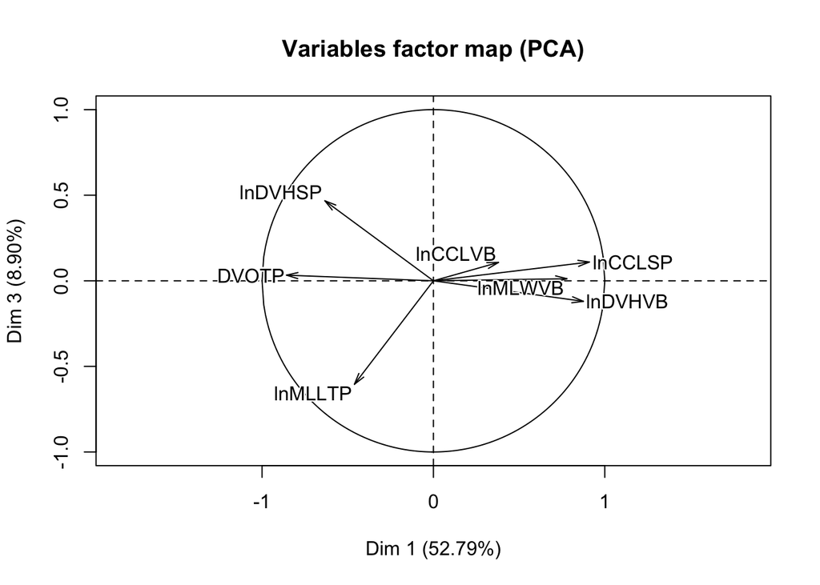

```
## **Results for the Principal Component Analysis (PCA)**
## The analysis was performed on 39 individuals, described by 7 variables
## *The results are available in the following objects:
##
##    name               description
## 1  "$eig"             "eigenvalues"
## 2  "$var"             "results for the variables"
## 3  "$var$coord"       "coord. for the variables"
## 4  "$var$cor"         "correlations variables - dimensions"
## 5  "$var$cos2"        "cos2 for the variables"
## 6  "$var$contrib"     "contributions of the variables"
## 7  "$ind"             "results for the individuals"
## 8  "$ind$coord"       "coord. for the individuals"
## 9  "$ind$cos2"        "cos2 for the individuals"
## 10 "$ind$contrib"     "contributions of the individuals"
## 11 "$call"            "summary statistics"
## 12 "$call$centre"     "mean of the variables"
## 13 "$call$ecart.type" "standard error of the variables"
## 14 "$call$row.w"      "weights for the individuals"
## 15 "$call$col.w"      "weights for the variables"
```

```r
#note that it automatically produces an individuals factor map (PC1x2 for individuals) and a variables factor map - this is a nice way to visualize how the variables are loaded along the PCs

#also note that in this one, I think the factor loadings were given opposite signs (+/-) so the projection of the variables is in the opposite direction of the previous one

#use argument axes=c(1,2) or c(1,3) etc. to specify which components you want to be plotted. e.g., to see PC1x3:
PCA(data_log[,5:11], axes=c(1,3))
```

```r
summary(vertpca3)
```

```
##
## Call:
## rmarkdown::render("Ostrofsky_PCApresentation.Rmd", encoding = "UTF-8")
##
##
## Eigenvalues
##                        Dim.1   Dim.2   Dim.3   Dim.4   Dim.5   Dim.6
## Variance               3.695   1.792   0.623   0.329   0.238   0.225
## % of var.             52.788  25.595   8.903   4.694   3.401   3.220
## Cumulative % of var.  52.788  78.384  87.287  91.981  95.383  98.603
##                        Dim.7
## Variance               0.098
## % of var.              1.397
## Cumulative % of var. 100.000
##
## Individuals (the 10 first)
##             Dist    Dim.1    ctr   cos2    Dim.2    ctr   cos2    Dim.3
## 1       |  1.797 |  0.499  0.173  0.077 | -1.097  1.721  0.372 |  1.015
## 2       |  2.424 |  1.376  1.313  0.322 | -1.006  1.450  0.172 |  0.804
## 3       |  2.075 |  1.276  1.130  0.378 | -1.265  2.290  0.372 |  0.761
## 4       |  1.657 |  0.918  0.585  0.307 | -1.212  2.103  0.535 |  0.549
## 5       |  3.694 |  1.909  2.530  0.267 |  3.119 13.925  0.713 |  0.093
## 6       |  4.816 |  2.868  5.706  0.355 |  3.807 20.739  0.625 |  0.548
## 7       |  4.666 |  2.900  5.835  0.386 |  3.527 17.802  0.571 |  0.165
## 8       |  3.315 |  2.414  4.044  0.530 |  2.201  6.930  0.441 | -0.107
## 9       |  2.136 |  1.511  1.584  0.500 | -1.300  2.418  0.370 |  0.543
## 10      |  1.928 | -1.136  0.896  0.347 | -0.075  0.008  0.002 | -0.730
##            ctr   cos2
## 1        4.241  0.319 |
## 2        2.661  0.110 |
## 3        2.386  0.135 |
## 4        1.239  0.110 |
## 5        0.035  0.001 |
## 6        1.235  0.013 |
## 7        0.113  0.001 |
## 8        0.047  0.001 |
## 9        1.213  0.065 |
## 10       2.195  0.144 |
##
## Variables
##            Dim.1    ctr   cos2    Dim.2    ctr   cos2    Dim.3    ctr
## lnDVHSP | -0.633 10.853  0.401 |  0.542 16.372  0.293 |  0.467 35.053
## lnCCLSP |  0.911 22.446  0.829 |  0.218  2.641  0.047 |  0.110  1.935
## lnMLLTP | -0.461  5.754  0.213 |  0.628 21.999  0.394 | -0.605 58.654
## DVOTP   | -0.857 19.888  0.735 |  0.329  6.038  0.108 |  0.033  0.174
## lnDVHVB |  0.875 20.729  0.766 |  0.063  0.223  0.004 | -0.120  2.307
## lnMLWVB |  0.779 16.424  0.607 |  0.421  9.909  0.178 |  0.012  0.024
## lnCCLVB |  0.380  3.906  0.144 |  0.876 42.817  0.767 |  0.107  1.853
##           cos2
## lnDVHSP  0.218 |
## lnCCLSP  0.012 |
## lnMLLTP  0.366 |
## DVOTP    0.001 |
## lnDVHVB  0.014 |
## lnMLWVB  0.000 |
## lnCCLVB  0.012 |
```

```r
vertpca3$eig #matrix with eigenvalues (and PVE)
```

```
##        eigenvalue percentage of variance cumulative percentage of variance
## comp 1 3.69519278              52.788468                          52.78847
## comp 2 1.79168499              25.595500                          78.38397
## comp 3 0.62324296               8.903471                          87.28744
## comp 4 0.32857217               4.693888                          91.98133
## comp 5 0.23809659               3.401380                          95.38271
## comp 6 0.22542046               3.220292                          98.60300
## comp 7 0.09779006               1.397001                         100.00000
```

```r
vertpca3$var$coord #correlations between variables and PCs
```

```
##              Dim.1     Dim.2       Dim.3        Dim.4       Dim.5
## lnDVHSP -0.6332750 0.5416105  0.46740143  0.048987863  0.26452618
## lnCCLSP  0.9107193 0.2175155  0.10981930  0.119214460 -0.16377364
## lnMLLTP -0.4611053 0.6278213 -0.60461371 -0.001398295  0.08600591
## DVOTP   -0.8572651 0.3289123  0.03296516  0.116540354 -0.15553692
## lnDVHVB  0.8752075 0.0632372 -0.11989918  0.357939420  0.23824019
## lnMLWVB  0.7790446 0.4213630  0.01227225 -0.407089007  0.11561410
## lnCCLVB  0.3799022 0.8758661  0.10746030  0.067339224 -0.19896461
```

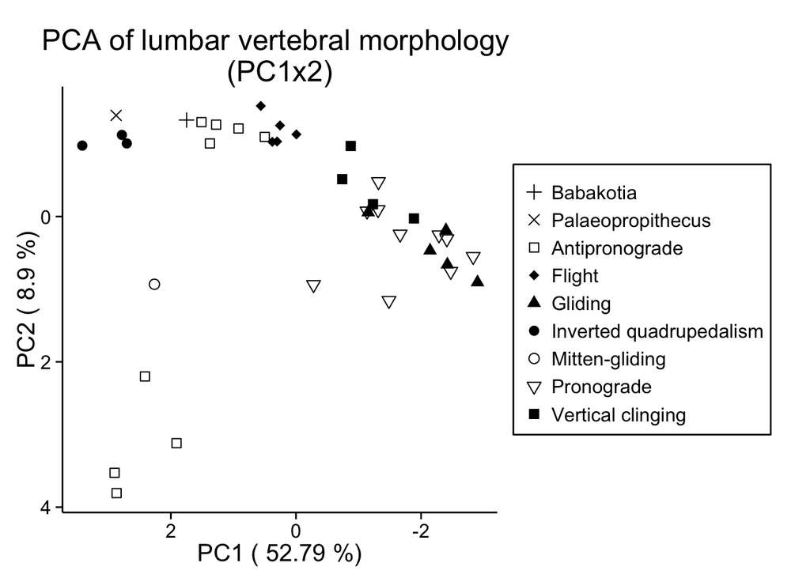

```r
PCscores3 <- as.data.frame(vertpca3$ind$coord) #save the PC scores
PC1_3 <- PCscores3[,1]
PC2_3 <- PCscores3[,2]
PC3_3 <- PCscores3[,3]

PC1_3.pve <- vertpca3$eig[[2]][[1]]
PC2_3.pve <- vertpca3$eig[[2]][[2]]
PC2_3.pve <- vertpca3$eig[[2]][[3]]

#can also do the same thing with ggplot again
PLOTC_1x2<- ggplot(data=PCscores3,
       aes(x=PC1_3, y=PC2_3, shape=data_log$Locomotor_category)) +
  geom_point(size=3) + theme_classic(15) +
  labs(title="PCA of lumbar vertebral morphology \n(PC1x2)",
       x=paste("PC1 (",round(PC1_3.pve,2),"%)"),
       y=paste("PC2 (",round(PC2_3.pve,2),"%)")) +
  scale_shape_manual(labels=legendlabels,
                     values=c(3, 4, 22, 18, 17, 16, 1, 6, 15)) +
    theme(legend.title=element_blank(),
          legend.background=element_rect(color="black")) +
  scale_x_reverse() + scale_y_reverse()

PLOTC_1x2
```